# African Leaders on Facebook: Preliminary Analysis

2026-03-13

```r
# PATHS & CONSTANTS
#-------------------------------------------------------------------------------------
library(dplyr)
library(ggplot2)
library(tidyr)
library(stringr)

# PATHS & CONSTANTS
#-------------------------------------------------------------------------------------
data_path <- "~/Desktop/repos/DATA-sm-political-moderation/"
# - read in all prediction files sor far (Mar 11, 2026)
inpath <- paste0(data_path, "gemma3_africa_predictions/")

# DATA
#-------------------------------------------------------------------------------------
# - current main post-level file. N = 313,398
main <- read.csv(paste0(
  data_path, "panelwithpostsandaddedvars.csv"), colClasses = "character")

# .... /!\ Why 313,398 if we only had 171,801 FB posts???

# /!\ ADD NEW PREDICTIONS: WE NOW HAVE ~63k instead of 25k
# ... predictions split into different files
infiles <- list.files(inpath) # N = 8

# - create a single dataset by stacking all prediction files
preds <- NULL
for (infile in infiles) {
  indf <- read.csv(paste0(inpath, infile), colClasses = "character")
  preds <- rbind(preds, indf)
}

# - deduplicate prediction dataset
preds02 <- preds[!duplicated(preds$id),] # N = 62,632 predicted posts so far

# - get rid of preds variables in the main dataset, to be added again
preds_cols <- colnames(preds02)[2:ncol(preds02)]

main02 <- main[, !colnames(main) %in% preds_cols]

main03 <- left_join(main02, preds02)

# - EXPORT this new dataset with updated predictions
# write.csv(main03, paste0(data_path, "panelwithpostsandaddedvars-v2.csv"),
#           row.names = FALSE)
```

### Which one is the most active: official Government account, offical account of the Powerholder, or the personal account of the Powerholder?

Clearly the Government official accounts seem the most active ones (N = 97,524), followed by official accounts of powerholders (N = 34,817) and their personal accounts (N = 17,111).

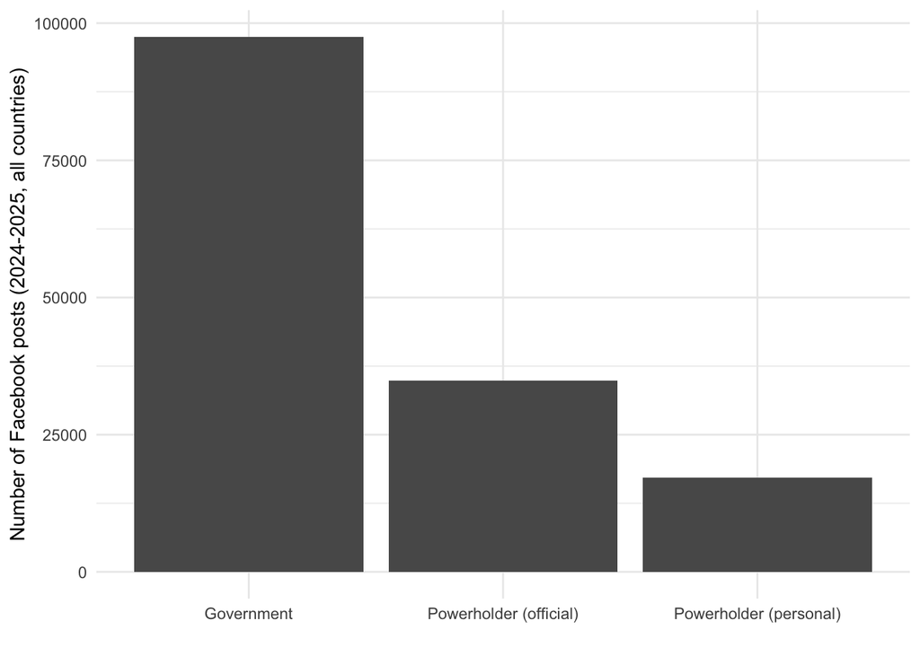

**Question**: there are 22k posts not included in this analysis `(powerholder == 0)`. **@Janina**, these are posts from non-powerholders I assume, right?

### What country government accounts are most active on Facebook?

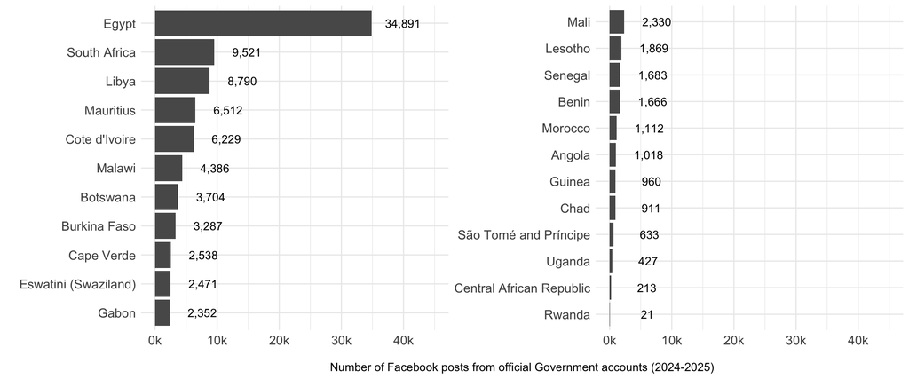

Interesting how Facebook usage by the Egyptian government is so high compared to the rest. But then most governments seem to be quite active, with a median number of posts for this 2-year period of 2,330 posts, so more than 3 a day.

**Question:** what do we think can explain this variation? Government resources (or economic development more broadly)? Internet penetration? Egypt and Libya for example, which are at the top, were also some of the leading countries of the Arab Spring; so I suppose internet pentration has been quite high in there for a while. What about the countries at the bottom (Rwanda, Uganda…)?

### What are the most discussed topics?

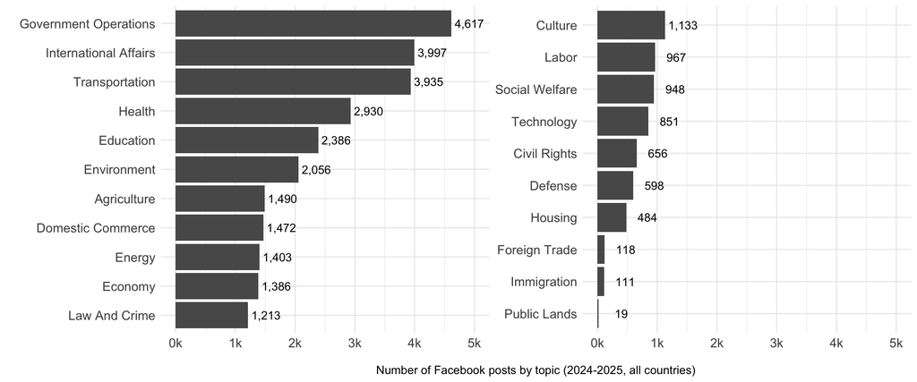

Government operations tends to be the most prominent Comparative Agendas Project topic, also when studying the social media communications of politicians in Western countries, so no surprise there. However, other topics such as `International Affairs` and `Transportation` aren’t usually among the most relevant ones. This seems to be more particular of African countries.

### Are these issue areas equally discussed across countries?

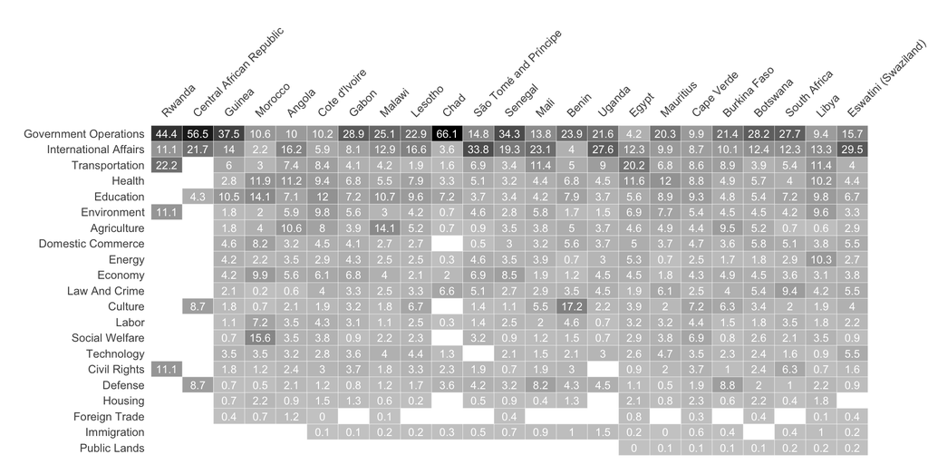

A lot to digest here. I find the differences in the first 2-5 top rows very interesting. There seems to be relevant variation on which countries discuss Intl. Affairs, and to a lesser extent, which ones discuss transporation, health, and education. Then, I find very interesting the few outliers: e.g. Morocco’s focus on education and social welfare, and Malawi’s focus on agriculture.

### Facebook activity across time (2024-2025), all countries

[figure not shown]

**Question:** on the one hand, this makes our research more relevant, as social media is becoming more relevant to African governments. On the other, do we think it is a challenge to our measurement strategy? Could people argue that socila media (here, Facebook) might not be a good measurement of these countries’ public/expressed issue/policy agenda, because in early 2024 maybe not all of them were using social media for public comms?

### Change in Facebook usage between 2024 and 2025, by country

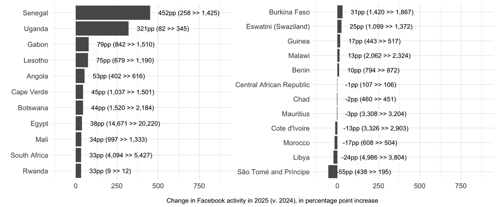

I see two stories, both pointing in the same rising direction. First, I see some countries that didn’t use Facebook as often in 2024 (Senegal, Uganda) to radically increase their activity (any change in government for these? Or for the countries where we see the most drastic change?). Second, I also see several that already had a very high Facebook usage in 2024 (Egypt, Botswana) to increase their activity in 2025. Sao tome and Principe clear downturn outlier: any change in government there?

### Topic prevalence across time (2024-2025), all countries

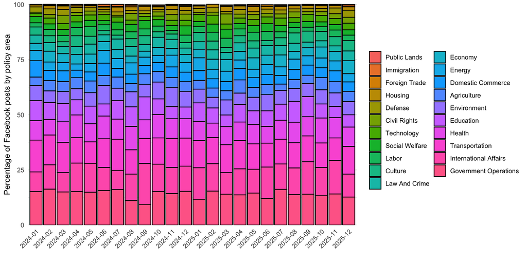